# IE6400 Foundations for Data Analytics Engineering

# Fall 2023

### Module 2: Regression and Prediction

#### Regression

Regression analysis is a statistical method used for modeling the relationship between a dependent variable and one or more independent variables. The goal of regression is to find the mathematical equation that describes the relationship between the dependent and independent variables.

Types:

- Linear Regression:
  - Simple Linear Regression: Models the relationship between a dependent variable and one independent variable using a linear equation.
  - Multiple Linear Regression: Involves two or more independent variables.
- Polynomial Regression: Uses a polynomial equation instead of a linear equation to model the relationship between variables.
- Logistic Regression: Used for binary classification problems, it models the probability that the dependent variable belongs to a particular category.

Applications:

- Predicting sales based on advertising spend.
- Estimating the relationship between rainfall and crop yield.
- Predicting house prices based on features like size and location.

#### Prediction

Prediction involves estimating the future value of a variable (or variables) based on historical data and analysis. It is often used in the context of machine learning, where algorithms are trained on historical data to make predictions or decisions without being explicitly programmed to perform the task.

Types:

- Classification: Predicting which category or class the new data will fall into based on the training data.
- Regression (in the context of prediction): Predicting a continuous value. Time Series Forecasting: Predicting future values based on previously observed values in time-series data.

Applications:

- Forecasting stock prices.
- Predicting weather conditions.
- Recommending products to customers based on past purchases.

#### Relationship Between Regression and Prediction:

In the context of machine learning and statistics, regression analysis is often used for prediction. Specifically, regression models can be used to predict the dependent variable based on new data for the independent variable(s). For example, a simple linear regression model could be used to predict a person's weight based on their height.

#### In summary:

- Regression is more about understanding the relationship between variables.
- Prediction is about estimating unknown values based on known values.

In order to install all the required libraries and files run the below code

```python
!pip install matplotlib pandas numpy seaborn scikit-learn statsmodels
```

#### Linear Regression

```python
import numpy as np # linear algebra
import pandas as pd # data processing, CSV file I/O (e.g. pd.read_csv)
```

#### Exercise 1 Simple Linear Regression Model

In this we aim to create a predictive model for estimating Sales using an advertising dataset. The dataset contains information about advertising expenses on three different platforms: TV, Radio, and Newspaper, along with the corresponding Sales Volume, which is measured in thousands of units. The expenditures on advertising are recorded in thousands of dollars.

This particular machine learning task falls under the category of Regression, specifically linear regression. Our objective is to predict the Sales figures for TV advertising based on the provided data on TV expenditures.

In essence, our goal is to use this dataset to build a model that can make predictions about Sales based on the amount spent on TV advertising and model the relation between them and also provides insights.

```python
#loading the dataset..
df = pd.read_csv('advertising.csv')
```

```python
# first five rows
df.head(5)
```

|  | TV | Radio | Newspaper | Sales |
| --- | --- | --- | --- | --- |
| 0 | 230.1 | 37.8 | 69.2 | 22.1 |
| 1 | 44.5 | 39.3 | 45.1 | 10.4 |
| 2 | 17.2 | 45.9 | 69.3 | 12.0 |
| 3 | 151.5 | 41.3 | 58.5 | 16.5 |
| 4 | 180.8 | 10.8 | 58.4 | 17.9 |

```python
#drop radio and newspaper column from df
df.drop(columns=['Radio','Newspaper'],inplace=True,axis=1)
df.head()
```

|  | TV | Sales |
| --- | --- | --- |
| 0 | 230.1 | 22.1 |
| 1 | 44.5 | 10.4 |
| 2 | 17.2 | 12.0 |
| 3 | 151.5 | 16.5 |
| 4 | 180.8 | 17.9 |

```python
# View the dimensions of df
df.shape
```

```
(200, 2)
```

```python
# View dataframe summary
df.info()
```

```
<class 'pandas.core.frame.DataFrame'>
RangeIndex: 200 entries, 0 to 199
Data columns (total 2 columns):
 #   Column  Non-Null Count  Dtype
---  ------  --------------  -----
 0   TV      200 non-null    float64
 1   Sales   200 non-null    float64
dtypes: float64(2)
memory usage: 3.2 KB
```

```python
# Descriptive Statistics
df.describe()
```

|  | TV | Sales |
| --- | --- | --- |
| count | 200.000000 | 200.000000 |
| mean | 147.042500 | 15.130500 |
| std | 85.854236 | 5.283892 |
| min | 0.700000 | 1.600000 |
| 25% | 74.375000 | 11.000000 |
| 50% | 149.750000 | 16.000000 |
| 75% | 218.825000 | 19.050000 |
| max | 296.400000 | 27.000000 |

#### Declare feature variable and target variable

- X is the Feature varible
- y is the Target variable

```python
X = df.TV
y = df.Sales
```

#### Analyze the relationship between TV advertising spend (TV) and Sales.

- This code uses the pandas library to load the dataset and the seaborn library to create a scatter plot with a regression line.

```
      TV  Radio  Newspaper  Sales
0  230.1   37.8       69.2   22.1
1   44.5   39.3       45.1   10.4
2   17.2   45.9       69.3   12.0
3  151.5   41.3       58.5   16.5
4  180.8   10.8       58.4   17.9
```

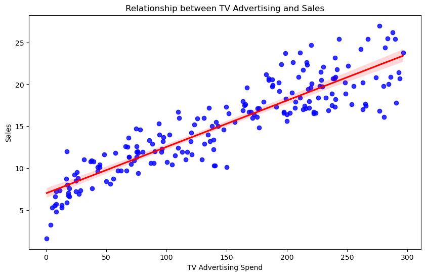

```python
# Importing necessary libraries
import pandas as pd
import seaborn as sns
import matplotlib.pyplot as plt

# Load the dataset
file_path = 'advertising.csv'  # Replace with the path to your file
df = pd.read_csv(file_path)

# Display the first few rows of the dataframe
print(df.head())

# Plotting the relationship between TV and Sales
plt.figure(figsize=(10, 6))
sns.regplot(x='TV', y='Sales', data=df, scatter_kws={'color': 'blue'}, line_kws={'color': 'red'})
plt.title('Relationship between TV Advertising and Sales')
plt.xlabel('TV Advertising Spend')
plt.ylabel('Sales')
plt.show()
```

#### Observations:

- There is a positive linear relationship between TV advertising spend and Sales.
- As the TV advertising spend increases, the Sales also tend to increase.
- The red line (regression line) captures the general trend in the data, indicating a positive slope.
- This visualization suggests that TV advertising is positively associated with Sales, and higher spending on TV advertising is likely to result in higher sales.

#### Use a pairplot to analyze the relationships

- The seaborn library's pairplot function is used for this purpose.

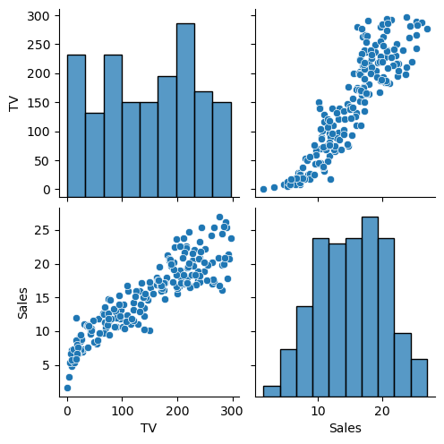

```python
# Importing necessary libraries
import pandas as pd
import seaborn as sns

# Load the dataset
file_path = 'advertising.csv'  # Replace with the path to your file
df = pd.read_csv(file_path)

#drop radio and newspaper columns
df.drop(columns=['Radio','Newspaper'],inplace=True,axis=1)

# Creating a pairplot to visualize the relationships between all numerical variables
sns.pairplot(df)
```

#### Interpretation:

Scatter Plot between TV and Sales:

- Observing the scatter plot between TV (x-axis) and Sales (y-axis), there is a clear upward trend in the data points.
- This upward trend indicates a positive correlation between TV advertising spend and Sales. As the expenditure on TV advertising increases, the sales also seem to increase.

Histogram for TV:

Histogram for Sales:

#### Checking dimensions of X and y

```python
# Print the dimensions of X and y
print(X.shape)
print(y.shape)
```

```
(200,)
(200,)
```

```python
X
```

```
0      230.1
1       44.5
2       17.2
3      151.5
4      180.8
       ...
195     38.2
196     94.2
197    177.0
198    283.6
199    232.1
Name: TV, Length: 200, dtype: float64
```

```python
y
```

```
0      22.1
1      10.4
2      12.0
3      16.5
4      17.9
       ...
195     7.6
196    14.0
197    14.8
198    25.5
199    18.4
Name: Sales, Length: 200, dtype: float64
```

#### Reshaping X and y

- Since we are working with only one feature variable, so we need to reshape using Numpy reshape() method

```python
# Reshape X and y
X = np.array(X)
X = np.reshape(X,(-1,1))

y = np.array(y)
y = np.reshape(y,(-1,1))
```

```python
# Print the dimensions of X and y after reshaping
print(X.shape)
print(y.shape)
```

```
(200, 1)
(200, 1)
```

```python
# X Values
X
```

```
array([[230.1],
       [ 44.5],
       [ 17.2],
       [151.5],
       [180.8],
       [  8.7],
       [ 57.5],
       [120.2],
       [  8.6],
       [199.8],
       [ 66.1],
       [214.7],
       [ 23.8],
       [ 97.5],
       [204.1],
       [195.4],
       [ 67.8],
       [281.4],
       [ 69.2],
       [147.3],
       [218.4],
       [237.4],
       [ 13.2],
       [228.3],
       [ 62.3],
       [262.9],
       [142.9],
       [240.1],
       [248.8],
       [ 70.6],
       [292.9],
       [112.9],
       [ 97.2],
       [265.6],
       [ 95.7],
       [290.7],
       [266.9],
       [ 74.7],
       [ 43.1],
       [228. ],
```

[output cut: 145 more lines]

```
       [205. ],
       [139.5],
       [191.1],
       [286. ],
       [ 18.7],
       [ 39.5],
       [ 75.5],
       [ 17.2],
       [166.8],
       [149.7],
       [ 38.2],
       [ 94.2],
       [177. ],
       [283.6],
       [232.1]])
```

```python
# y Values
y
```

```
array([[22.1],
       [10.4],
       [12. ],
       [16.5],
       [17.9],
       [ 7.2],
       [11.8],
       [13.2],
       [ 4.8],
       [15.6],
       [12.6],
       [17.4],
       [ 9.2],
       [13.7],
       [19. ],
       [22.4],
       [12.5],
       [24.4],
       [11.3],
       [14.6],
       [18. ],
       [17.5],
       [ 5.6],
       [20.5],
       [ 9.7],
       [17. ],
       [15. ],
       [20.9],
       [18.9],
       [10.5],
       [21.4],
       [11.9],
       [13.2],
       [17.4],
       [11.9],
       [17.8],
       [25.4],
       [14.7],
       [10.1],
       [21.5],
```

[output cut: 145 more lines]

```
       [22.6],
       [10.3],
       [17.3],
       [20.9],
       [ 6.7],
       [10.8],
       [11.9],
       [ 5.9],
       [19.6],
       [17.3],
       [ 7.6],
       [14. ],
       [14.8],
       [25.5],
       [18.4]])
```

#### Difference in dimensions of X and y after reshaping

You can see the difference in diminsions of X and y before and after reshaping.

It is essential in this case because getting the feature and target variable right is an important precursor to model building.

#### Train test split

- Split dataset into two sets namely - train set and test set
- Model learn relationships from training data and predict on test data

```python
# import train_test_split module
from sklearn.model_selection import train_test_split

# Split X and y into training and test data sets
X_train,X_test,y_train,y_test = train_test_split(X,y,test_size=0.3,random_state=42)
```

`random_state` is a parameter used in machine learning models to control the randomness of the data splitting process. It is used to ensure that the results are reproducible. If you set the `random_state` parameter to an integer, the randomization will always be the same, allowing you to get the same results every time you run the model.

`test_size` is another parameter used in machine learning models, specifically when splitting the data into training and testing sets. It represents the proportion of the dataset that should be included in the test set. For example, if you set `test_size` to 0.3, 30% of the data will be used for testing and 70% will be used for training.

```python
# print shapes of X_train,y_train, X_test, y_test

print(X_train.shape)
print(y_train.shape)
print(X_test.shape)
print(y_test.shape)
```

```
(140, 1)
(140, 1)
(60, 1)
(60, 1)
```

```python
# import LinearRegression module
from sklearn.linear_model import LinearRegression as lir


# Instantiate the linear regression object lm
lm = lir()
# Fit and train the model using training data sets
lm.fit(X_train,y_train)
# Predict on the test data
y_pred_test = lm.predict(X_test)
```

```python
y_pred_test
```

```
array([[16.16109107],
       [17.92129084],
       [23.26769201],
       [ 7.84812269],
       [19.28667945],
       [11.32465432],
       [19.09475735],
       [ 9.94829874],
       [19.4018327 ],
       [16.8081427 ],
       [ 8.93385339],
       [10.28827502],
       [20.0653348 ],
       [ 7.50266292],
       [14.85602084],
       [16.53945177],
       [ 7.6068492 ],
       [18.04192759],
       [11.3356213 ],
       [20.22435596],
       [19.79116038],
       [10.92435967],
       [ 9.29028013],
       [20.96462689],
       [10.99016153],
       [10.14022083],
       [18.91380224],
       [14.84505386],
       [11.98815642],
       [ 7.66716757],
       [18.16256433],
       [11.00112851],
       [18.11321294],
       [ 8.13326408],
       [22.59870643],
       [20.26822387],
       [ 9.85507944],
       [22.21486224],
       [13.63320293],
       [ 8.71451385],
       [13.56740107],
       [16.91232898],
       [ 9.56993804],
       [10.62276781],
       [19.48956852],
       [ 9.30124711],
       [11.07789734],
       [15.28373293],
       [12.94228339],
       [11.39045618],
       [11.49464246],
       [16.44074898],
       [ 7.68361804],
       [ 7.63426664],
       [11.39593967],
       [14.30218851],
       [11.23143502],
       [23.09222038],
       [ 8.28131827],
       [18.04192759]])
```

#### Model slope and intercept term

- `Model slope is given by lm.coef_`
- `Model intercept is given by lm.intercept_.`

```python
# Compute model slope and intercept
print('Estimated model slope, a: {}'.format(lm.coef_))
print('Estimated model intercept, b: {}'.format(lm.intercept_))
```

```
Estimated model slope, a: [[0.05483488]]
Estimated model intercept, b: [7.20655455]
```

```python
a=lm.coef_
b=lm.intercept_
y=a*X+b
```

```python
# Linear Model

y = 0.05483488 * X + 7.20655455
```

Here we already get the Linear model.

#### Making predictions

To make prediction on an individual TV value,

```
            lm.predict(Xi)
```

where:

`Xi` = `TV data value of ith observation`

```python
df.TV.head()
```

```
0    230.1
1     44.5
2     17.2
3    151.5
4    180.8
Name: TV, dtype: float64
```

```python
# Predicting Sales values on first five 5 TV  datasets only
pred_x = lm.predict(X)
pred_x[:5]
```

```
array([[19.82406131],
       [ 9.64670688],
       [ 8.14971455],
       [15.51403944],
       [17.12070154]])
```

Can also print prediction for all values of TV available in dataset

```python
pred_x
```

```
array([[19.82406131],
       [ 9.64670688],
       [ 8.14971455],
       [15.51403944],
       [17.12070154],
       [ 7.68361804],
       [10.35956037],
       [13.79770758],
       [ 7.67813455],
       [18.16256433],
       [10.83114037],
       [18.9796041 ],
       [ 8.51162478],
       [12.55295572],
       [18.39835433],
       [17.92129084],
       [10.92435967],
       [22.63709085],
       [11.00112851],
       [15.28373293],
       [19.18249317],
       [20.22435596],
       [ 7.93037501],
       [19.72535852],
       [10.62276781],
       [21.6226455 ],
       [15.04245944],
       [20.37241015],
       [20.84947364],
       [11.07789734],
       [23.26769201],
       [13.39741293],
       [12.53650525],
       [21.77069968],
       [12.45425293],
       [23.14705527],
       [21.84198503],
       [11.30272037],
       [ 9.56993804],
       [19.70890805],
```

[output cut: 145 more lines]

```
       [18.44770573],
       [14.85602084],
       [17.68550084],
       [22.88933131],
       [ 8.23196688],
       [ 9.37253246],
       [11.34658827],
       [ 8.14971455],
       [16.35301317],
       [15.41533665],
       [ 9.30124711],
       [12.3720006 ],
       [16.91232898],
       [22.75772759],
       [19.93373108]])
```

### Model Performance

#### `Regression Metrics`

To Evaluate Model Performance

For Regression Problems there are two ways to Compute Model Performance

1. **`RMSE (Root Mean Square Error)`**
   - RMSE is standard deviation of residuals, it gives us standard deviation of unexplained variance by model
2. **`R-Squared Value`**
   - `(R2) Correlation` explains strength of relationship between an independent and dependent variable

```python
# import mean_squared_error module
from sklearn.metrics import mean_squared_error as mse


# Calculate and print Root Mean Square Error(RMSE)
mse = mse(y_test,y_pred_test)
rmse = np.sqrt(mse)

print(f'RMSE value:: {rmse}')
```

```
RMSE value:: 2.2758570698017597
```

```python
# import r2_score module
from sklearn.metrics import r2_score


# Calculate and print r2_score
r2 = r2_score(y_test,y_pred_test)
print(f'R2 Score value:: {r2 }')
```

```
R2 Score value:: 0.8148553892086791
```

#### Interpretation and Conclusion

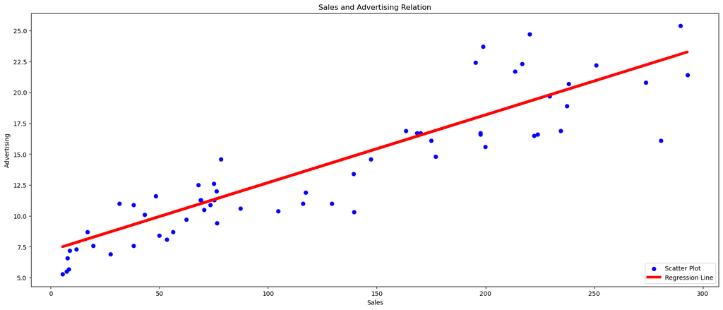

```python
# Plot the Regression Line between X and Y as shown in below output.

plt.figure(figsize=(20,8))
plt.scatter(X_test,y_test,color='blue',label='Scatter Plot')
plt.plot(X_test,y_pred_test,color='red',linewidth=4,label='Regression Line')

plt.legend(loc=4)
plt.title('Sales and Advertising Relation')
plt.xlabel('Sales')
plt.ylabel('Advertising')

plt.show()
```

- RMSE value has been found to be 2.2758
  - Means standard Deviation for our prediction is 2.2758 which is quite less
  - In business decisions, the benchmark for R2 score value is 0.7
- It means if R2 score value > 0.7, then model is good enough to deploy on unseen data
- Our R2 score value has been found to be 0.814855389208679
  - `It means that this model explains 81.49 % of the variance in our dependent variable`
  - So R2 score value confirms that the model is good enough to deploy because it provides good fit to data

#### Residual analysis

- Linear regression model may not represent data appropriately, model may be a poor fit to data
- So we should validate our model by defining and examining residual plots

```python
X_test.shape,X_train.shape,y_train.shape,y_test.shape
```

```
((60, 1), (140, 1), (140, 1), (60, 1))
```

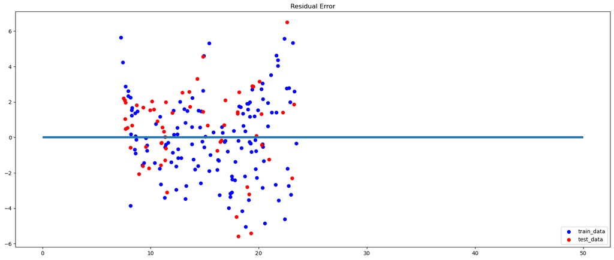

```python
# Plotting residual errors

plt.figure(figsize=(20,8))
plt.scatter(lm.predict(X_train),lm.predict(X_train) - y_train,color='blue',label='train_data')
plt.scatter(lm.predict(X_test),lm.predict(X_test) - y_test,color='red',label='test_data')

plt.hlines(xmin=0,xmax=50,y=0,linewidth=4)
plt.legend(loc=4)
plt.title('Residual Error')

plt.show()
```

#### Checking for Overfitting and Underfitting

Will see training set score and test set score

- Expected training set score is 0.7996 which is averagely good. So, model learned relationships quite appropriately from training data
- Model performs good on test data as test score will be 0.8149
  - It is a clear sign of good fit/ balanced fit
  - Hence, we can validated our finding that linear regression model provides good fit to data

**`Underfitting:`**

- Model underfitts training data when model performs poorly on training data
- This is because model is unable to capture relationship between input examples (often called X) and target values (often called Y)

**`Overfitting:`**

- Model overfitts training data when you see that model performs well on training data but does not perform well on evaluation data
- This is because model is memorizing data it has seen and is unable to generalize to unseen examples

```python
# Checking for Overfitting or Underfitting the data by calculation score using score function.
print(f'Training set score:: {lm.score(X_train,y_train)}')
print(f'Test set score:: {lm.score(X_test,y_test)}')
```

```
Training set score:: 0.799626928219267
Test set score:: 0.8148553892086791
```

Model is not overfitting or underfitting!

#### Exercise 2 Multiple linear regression

Build a Multiple Linear Regression Model to predict sales based on the money spent on TV, Radio, and Newspaper for advertising.

Equation: Sales = β0 + (β1 *TV) + (β2* Radio) + (β3 * Newspaper) + e

#### Import Libraries:

- Import necessary libraries for data manipulation (pandas), model building (LinearRegression from sklearn.linear_model), and metrics calculation (mean_squared_error, r2_score from sklearn.metrics).

#### Load Dataset:

- Load the advertising.csv dataset into a DataFrame df.

```python
# Importing necessary libraries
import pandas as pd
from sklearn.model_selection import train_test_split
from sklearn.linear_model import LinearRegression
from sklearn.metrics import mean_squared_error, r2_score

# Load the dataset
df = pd.read_csv('advertising.csv')  # Replace with the path to your file
df
```

|  | TV | Radio | Newspaper | Sales |
| --- | --- | --- | --- | --- |
| 0 | 230.1 | 37.8 | 69.2 | 22.1 |
| 1 | 44.5 | 39.3 | 45.1 | 10.4 |
| 2 | 17.2 | 45.9 | 69.3 | 12.0 |
| 3 | 151.5 | 41.3 | 58.5 | 16.5 |
| 4 | 180.8 | 10.8 | 58.4 | 17.9 |
| ... | ... | ... | ... | ... |
| 195 | 38.2 | 3.7 | 13.8 | 7.6 |
| 196 | 94.2 | 4.9 | 8.1 | 14.0 |
| 197 | 177.0 | 9.3 | 6.4 | 14.8 |
| 198 | 283.6 | 42.0 | 66.2 | 25.5 |
| 199 | 232.1 | 8.6 | 8.7 | 18.4 |

200 rows × 4 columns

#### Define Features and Target:

- Define X as the features (TV, Radio, Newspaper) and y as the target variable (Sales).

```python
# Defining the features (independent variables) and the target (dependent variable)
X = df[['TV', 'Radio', 'Newspaper']]
y = df['Sales']

print(X)
print(y)
```

```
        TV  Radio  Newspaper
0    230.1   37.8       69.2
1     44.5   39.3       45.1
2     17.2   45.9       69.3
3    151.5   41.3       58.5
4    180.8   10.8       58.4
..     ...    ...        ...
195   38.2    3.7       13.8
196   94.2    4.9        8.1
197  177.0    9.3        6.4
198  283.6   42.0       66.2
199  232.1    8.6        8.7

[200 rows x 3 columns]
0      22.1
1      10.4
2      12.0
3      16.5
4      17.9
       ...
195     7.6
196    14.0
197    14.8
198    25.5
199    18.4
Name: Sales, Length: 200, dtype: float64
```

#### Split Dataset:

- Split the dataset into training and testing sets using train_test_split.
- 80% of the data is used for training
- 20% for testing.

```python
# Splitting the dataset into training and testing sets
X_train, X_test, y_train, y_test = train_test_split(X, y, test_size=0.2, random_state=0)

# Print shapes of X_train,y_train, X_test, y_test
print(X_train.shape)
print(X_test.shape)
print(y_train.shape)
print(y_test.shape)
```

```
(160, 3)
(40, 3)
(160,)
(40,)
```

#### Initialize Model:

- Initialize the Linear Regression model.

#### Fit Model:

- Fit the model on the training data (X_train, y_train).

#### Make Predictions:

- Use the trained model to make predictions on the test data (X_test).

#### Calculate Metrics:

- Calculate the Mean Squared Error (MSE) and R-Squared value to evaluate the model's performance.

#### Output Results:

- Output the coefficients, MSE, and R-Squared values.

```python
# Initializing the Linear Regression model
model = LinearRegression()

# Fitting the model on the training data
model.fit(X_train, y_train)

# Making predictions on the test data
y_pred = model.predict(X_test)

# Calculating the Mean Squared Error and R-squared value
mse = mean_squared_error(y_test, y_pred)
r2 = r2_score(y_test, y_pred)

# Output the coefficients, MSE, and R^2
print("Coefficients:", model.coef_)
print("MSE:", mse)
print("R^2:", r2)
```

```
Coefficients: [ 0.05368006  0.11152624 -0.00351166]
MSE: 4.522552562041291
R^2: 0.8645053923967724
```

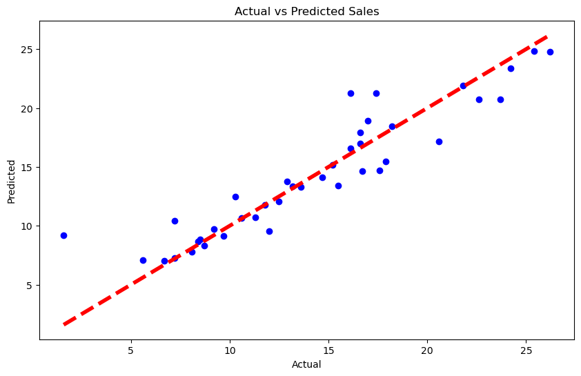

```python
# Plotting the actual vs predicted values
plt.figure(figsize=(10, 6))
plt.scatter(y_test, y_pred, color='blue')
plt.plot([y_test.min(), y_test.max()], [y_test.min(), y_test.max()], '--', lw=4, color='red')
plt.xlabel('Actual')
plt.ylabel('Predicted')
plt.title('Actual vs Predicted Sales')
plt.show()
```

#### Coefficients:

- **TV**: (0.05368)
- **Radio**: (0.11153)
- **Newspaper**: (-0.00351)

#### Interpretation:

- For every additional unit of spending on TV and Radio advertising, sales are predicted to increase, while spending on Newspaper advertising might not be effective in increasing sales.
- The MSE represents the average squared difference between the estimated values and the actual value. A lower MSE indicates a better fit of the model, while a higher MSE indicates a poorer fit.
- The ($R^2$) value, also known as the coefficient of determination, indicates the proportion of the variance in the dependent variable that is predictable from the independent variables. An ($R^2$) value of (0.86451) means that approximately (86.45\%) of the variability in sales can be explained by the advertising spends. This high ($R^2$) value indicates a good fit of the model, suggesting that the model explains a significant proportion of the variability in sales.

#### Visualization Interpretation:

- The scatter plot shows the actual sales (y_test) on the x-axis and the predicted sales (y_pred) on the y-axis. The red dashed line represents the line of perfect prediction where actual sales equal predicted sales. Points that are closer to the red dashed line represent more accurate predictions, while points further away represent less accurate predictions.

In conclusion, the model suggests that spending on TV and Radio advertising is positively associated with sales, while spending on Newspaper advertising might not be effective. The model has a good fit with an ($R^2$) value of (0.86451), explaining a significant proportion of the variability in sales.

#### Exercise 3 Logistic Regression

Logistic Regression is a Machine Learning classification algorithm that is used to predict the probability of a categorical dependent variable. In logistic regression, the dependent variable is a binary variable that contains data coded as 1 (yes, success, etc.) or 0 (no, failure, etc.).

#### Dataset:

```python
# Importing necessary libraries
from sklearn.datasets import load_iris
from sklearn.model_selection import train_test_split
from sklearn.linear_model import LogisticRegression
from sklearn.metrics import classification_report, confusion_matrix
import matplotlib.pyplot as plt

# Load the Iris dataset
df = pd.read_csv('iris.csv')
# Defining the features (independent variables) and the target (dependent variable)
X = df[['sepal.length', 'sepal.width', 'petal.length', 'petal.width']]
y = df['variety']

print(X)
print(y)
```

```
     sepal.length  sepal.width  petal.length  petal.width
0             5.1          3.5           1.4          0.2
1             4.9          3.0           1.4          0.2
2             4.7          3.2           1.3          0.2
3             4.6          3.1           1.5          0.2
4             5.0          3.6           1.4          0.2
..            ...          ...           ...          ...
145           6.7          3.0           5.2          2.3
146           6.3          2.5           5.0          1.9
147           6.5          3.0           5.2          2.0
148           6.2          3.4           5.4          2.3
149           5.9          3.0           5.1          1.8

[150 rows x 4 columns]
0         Setosa
1         Setosa
2         Setosa
3         Setosa
4         Setosa
         ...
145    Virginica
146    Virginica
147    Virginica
148    Virginica
149    Virginica
Name: variety, Length: 150, dtype: object
```

```python
# Splitting the dataset into training and testing sets
X_train, X_test, y_train, y_test = train_test_split(X, y, test_size=0.3, random_state=0)

# Initializing the Logistic Regression model
model = LogisticRegression(max_iter=200)

# Fitting the model on the training data
model.fit(X_train, y_train)

# Making predictions on the test data
y_pred = model.predict(X_test)

# Output the classification report and confusion matrix
print(classification_report(y_test, y_pred))
```

```
              precision    recall  f1-score   support

      Setosa       1.00      1.00      1.00        16
  Versicolor       1.00      0.94      0.97        18
   Virginica       0.92      1.00      0.96        11

    accuracy                           0.98        45
   macro avg       0.97      0.98      0.98        45
weighted avg       0.98      0.98      0.98        45
```

#### Interpretations:

#### Classification Report:

Setosa:

- Precision, Recall, and F1-score are all 1.00, indicating perfect classification for the Setosa class.

Versicolor:

- Precision is 1.00, Recall is 0.94, and F1-score is 0.97, indicating high accuracy but there is one misclassification.

Virginica:

- Precision is 0.92, Recall is 1.00, and F1-score is 0.96, indicating good classification with some room for improvement.
- The overall accuracy of the model is 0.98, indicating a highly accurate model.

#### Confusion Matrix:

- The diagonal values (16, 17, 11) represent the correct predictions for each class (Setosa, Versicolor, Virginica respectively).
- There is one misclassification where a Versicolor is classified as Virginica.

#### Conclusion:

- The Logistic Regression model shows excellent performance with an overall accuracy of 0.98.
- The model perfectly classifies Setosa and has very high accuracy for Versicolor and Virginica.
- The confusion matrix confirms the high accuracy with only one misclassification observed.

#### Visualize the Confusion Matrix:

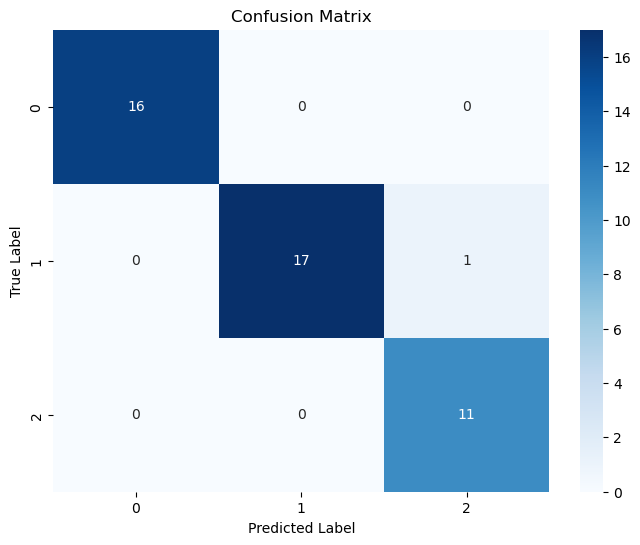

```python
import seaborn as sns
import matplotlib.pyplot as plt
from sklearn.metrics import confusion_matrix

# Assuming y_test and y_pred are already defined
cm = confusion_matrix(y_test, y_pred)

plt.figure(figsize=(8, 6))
sns.heatmap(cm, annot=True, fmt='d', cmap='Blues')
plt.title('Confusion Matrix')
plt.xlabel('Predicted Label')
plt.ylabel('True Label')
plt.show()
```

#### Plot the Receiver Operating Characteristic (ROC) Curve:

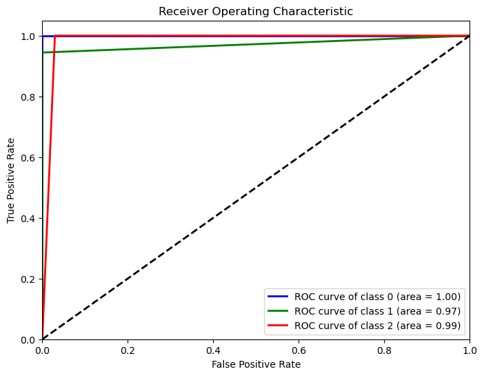

```python
from sklearn.metrics import roc_curve, roc_auc_score, auc
from sklearn.preprocessing import label_binarize
import numpy as np

# Binarize the output labels
y_test_bin = label_binarize(y_test, classes=['Setosa', 'Versicolor', 'Virginica'])
y_pred_bin = label_binarize(y_pred, classes=['Setosa', 'Versicolor', 'Virginica'])

# Compute ROC curve and ROC area for each class
fpr = dict()
tpr = dict()
roc_auc = dict()
for i in range(3):
    fpr[i], tpr[i], _ = roc_curve(y_test_bin[:, i], y_pred_bin[:, i])
    roc_auc[i] = auc(fpr[i], tpr[i])

# Plot the ROC curve
plt.figure(figsize=(8, 6))
for i, color in zip(range(3), ['blue', 'green', 'red']):
    plt.plot(fpr[i], tpr[i], color=color, lw=2,
             label='ROC curve of class {0} (area = {1:0.2f})'.format(i, roc_auc[i]))
plt.plot([0, 1], [0, 1], 'k--', lw=2)
plt.xlim([0.0, 1.0])
plt.ylim([0.0, 1.05])
plt.xlabel('False Positive Rate')
plt.ylabel('True Positive Rate')
plt.title('Receiver Operating Characteristic')
plt.legend(loc="lower right")
plt.show()
```

#### Interpretation:

- The ROC curve is a graphical representation of the true positive rate against the false positive rate for the different possible cut-off points of a diagnostic test.
- An area under the ROC curve (AUC) close to 1 indicates a good model.
- Each class will have its own ROC curve. If all the curves are closer to the top-left corner of the plot, it indicates good model performance.

#### Conclusion:

- The confusion matrix should have high diagonal values and low non-diagonal values for a good model.
- The ROC curves should be closer to the top-left corner for all classes, indicating high true positive rates and low false positive rates.

#### Exercise 4 Implementing the Gauss-Markov Model

The Gauss-Markov theorem is a fundamental result in econometrics and statistics that pertains to the properties of the ordinary least squares (OLS) estimator in linear regression analysis. The theorem establishes the conditions under which the OLS estimator is the Best Linear Unbiased Estimator (BLUE).

In this exercise, you will implement the Gauss-Markov model in Python to perform linear regression on a dataset. You will go through each step of the process, including data preparation, model fitting, predictions, and evaluation. Additionally, you will visualize the results and interpret them to understand the model's performance.

#### Dataset

- For this exercise, use the Boston Housing Dataset. This dataset contains information collected by the U.S Census Service concerning housing in the area of Boston Mass.

#### Steps:

#### 1. Data Loading and Preparation:

- Load the Boston Housing dataset.
- Explore the dataset to understand its structure.
- Select the features and the target variable.

```python
import pandas as pd

# Load the dataset
df = pd.read_csv('BostonHousing.csv')
df
```

|  | crim | zn | indus | chas | nox | rm | age | dis | rad | tax | ptratio | b | lstat | medv |
| --- | --- | --- | --- | --- | --- | --- | --- | --- | --- | --- | --- | --- | --- | --- |
| 0 | 0.00632 | 18.0 | 2.31 | 0 | 0.538 | 6.575 | 65.2 | 4.0900 | 1 | 296 | 15.3 | 396.90 | 4.98 | 24.0 |
| 1 | 0.02731 | 0.0 | 7.07 | 0 | 0.469 | 6.421 | 78.9 | 4.9671 | 2 | 242 | 17.8 | 396.90 | 9.14 | 21.6 |
| 2 | 0.02729 | 0.0 | 7.07 | 0 | 0.469 | 7.185 | 61.1 | 4.9671 | 2 | 242 | 17.8 | 392.83 | 4.03 | 34.7 |
| 3 | 0.03237 | 0.0 | 2.18 | 0 | 0.458 | 6.998 | 45.8 | 6.0622 | 3 | 222 | 18.7 | 394.63 | 2.94 | 33.4 |
| 4 | 0.06905 | 0.0 | 2.18 | 0 | 0.458 | 7.147 | 54.2 | 6.0622 | 3 | 222 | 18.7 | 396.90 | 5.33 | 36.2 |
| ... | ... | ... | ... | ... | ... | ... | ... | ... | ... | ... | ... | ... | ... | ... |
| 501 | 0.06263 | 0.0 | 11.93 | 0 | 0.573 | 6.593 | 69.1 | 2.4786 | 1 | 273 | 21.0 | 391.99 | 9.67 | 22.4 |
| 502 | 0.04527 | 0.0 | 11.93 | 0 | 0.573 | 6.120 | 76.7 | 2.2875 | 1 | 273 | 21.0 | 396.90 | 9.08 | 20.6 |
| 503 | 0.06076 | 0.0 | 11.93 | 0 | 0.573 | 6.976 | 91.0 | 2.1675 | 1 | 273 | 21.0 | 396.90 | 5.64 | 23.9 |
| 504 | 0.10959 | 0.0 | 11.93 | 0 | 0.573 | 6.794 | 89.3 | 2.3889 | 1 | 273 | 21.0 | 393.45 | 6.48 | 22.0 |
| 505 | 0.04741 | 0.0 | 11.93 | 0 | 0.573 | 6.030 | 80.8 | 2.5050 | 1 | 273 | 21.0 | 396.90 | 7.88 | 11.9 |

506 rows × 14 columns

#### 2. Splitting the Dataset:

- Split the dataset into training and testing sets.

```python
from sklearn.model_selection import train_test_split

X = df.drop(columns=['medv'])  # Assuming 'medv' is the target variable
y = df['medv']
X_train, X_test, y_train, y_test = train_test_split(X, y, test_size=0.3, random_state=0)

# Print shapes of X_train,y_train, X_test, y_test
print(X_train.shape)
print(X_test.shape)
print(y_train.shape)
print(y_test.shape)
```

```
(354, 13)
(152, 13)
(354,)
(152,)
```

#### 3. Model Fitting:

- Fit the Gauss-Markov model (Ordinary Least Squares) on the training data using statsmodels.

```python
import statsmodels.api as sm

X_train = sm.add_constant(X_train)  # Adding a constant to the model
model = sm.OLS(y_train, X_train).fit()
```

#### 4. Viewing Summary Statistics:

- View the summary statistics of the fitted model.

```python
print(model.summary())
```

```
                            OLS Regression Results
==============================================================================
Dep. Variable:                   medv   R-squared:                       0.765
Model:                            OLS   Adj. R-squared:                  0.756
Method:                 Least Squares   F-statistic:                     84.92
Date:                Fri, 20 Oct 2023   Prob (F-statistic):           2.76e-98
Time:                        10:58:56   Log-Likelihood:                -1032.2
No. Observations:                 354   AIC:                             2092.
Df Residuals:                     340   BIC:                             2147.
Df Model:                          13
Covariance Type:            nonrobust
==============================================================================
                 coef    std err          t      P>|t|      [0.025      0.975]
------------------------------------------------------------------------------
const         37.9371      5.876      6.457      0.000      26.380      49.494
crim          -0.1213      0.038     -3.185      0.002      -0.196      -0.046
zn             0.0445      0.016      2.834      0.005       0.014       0.075
indus          0.0113      0.068      0.166      0.868      -0.123       0.146
chas           2.5112      1.011      2.483      0.014       0.522       4.501
nox          -16.2313      4.487     -3.618      0.000     -25.056      -7.406
rm             3.8591      0.491      7.867      0.000       2.894       4.824
age           -0.0100      0.016     -0.634      0.527      -0.041       0.021
dis           -1.5003      0.234     -6.402      0.000      -1.961      -1.039
rad            0.2421      0.077      3.152      0.002       0.091       0.393
tax           -0.0111      0.004     -2.586      0.010      -0.019      -0.003
ptratio       -1.0178      0.150     -6.803      0.000      -1.312      -0.723
b              0.0068      0.003      2.099      0.037       0.000       0.013
lstat         -0.4867      0.060     -8.068      0.000      -0.605      -0.368
==============================================================================
Omnibus:                      133.612   Durbin-Watson:                   2.019
Prob(Omnibus):                  0.000   Jarque-Bera (JB):              634.086
Skew:                           1.547   Prob(JB):                    2.04e-138
Kurtosis:                       8.781   Cond. No.                     1.52e+04
==============================================================================

Notes:
[1] Standard Errors assume that the covariance matrix of the errors is correctly specified.
[2] The condition number is large, 1.52e+04. This might indicate that there are
strong multicollinearity or other numerical problems.
```

#### 5. Making Predictions:

- Use the fitted model to make predictions on the test data.

```python
X_test = sm.add_constant(X_test)
y_pred = model.predict(X_test)
print(y_pred)
```

```
329    24.935708
371    23.751632
219    29.326383
403    11.975346
78     21.372725
         ...
4      27.811077
428    14.506816
385     7.573699
308    28.334807
5      25.043412
Length: 152, dtype: float64
```

#### 6. Model Evaluation:

- Evaluate the model using appropriate metrics.

```python
from sklearn.metrics import mean_squared_error, r2_score

mse = mean_squared_error(y_test, y_pred)
r2 = r2_score(y_test, y_pred)
print(f"Mean Squared Error: {mse:.2f}")
print(f"R^2 Score: {r2:.2f}")
```

```
Mean Squared Error: 27.20
R^2 Score: 0.67
```

The Mean Squared Error (MSE) of 27.20 and the R-Squared score of 0.67 from the model output provide key insights into the model's performance. The MSE value indicates that, on average, the model's predictions are approximately 27.20 units squared away from the actual values, suggesting a potential area for model improvement. The R-Squared value of 0.67 reveals that the model explains 67% of the variability in the target variable, offering a moderate fit.

#### 7. Visualization:

- Visualize the actual vs predicted prices.

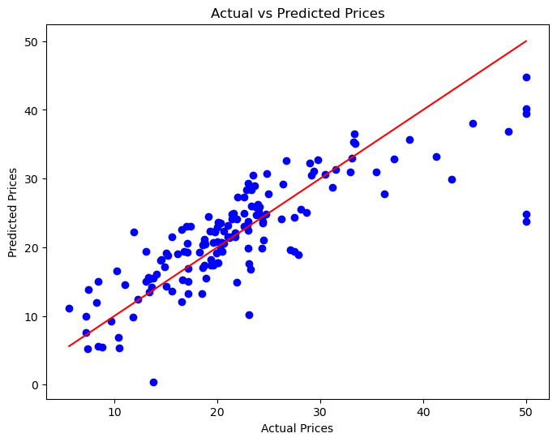

```python
import matplotlib.pyplot as plt

plt.figure(figsize=(8, 6))
plt.scatter(y_test, y_pred, color='blue')
plt.plot([min(y_test), max(y_test)], [min(y_test), max(y_test)], color='red')  # Diagonal line
plt.xlabel('Actual Prices')
plt.ylabel('Predicted Prices')
plt.title('Actual vs Predicted Prices')
plt.show()
```

#### Interpretation:

- In the scatter plot, each point represents a house, with the x-coordinate as the actual price and the y-coordinate as the predicted price.
- The red line represents perfect prediction, where actual prices equal predicted prices.
- Points close to the red line indicate accurate predictions, while points far from the line indicate discrepancies between actual and predicted prices.
- A tight cluster of points around the red line signifies a good model fit.

#### Explore the residuals and plot the residual graph

- Residuals are the differences between the actual and predicted values.
- You can use descriptive statistics to analyze the residuals.
- Plotting the residuals can help identify patterns and assess the model's performance

```
count    152.000000
mean       0.254652
std        5.225973
min      -10.287312
25%       -2.788263
50%       -0.450086
75%        2.237906
max       26.248368
dtype: float64
```

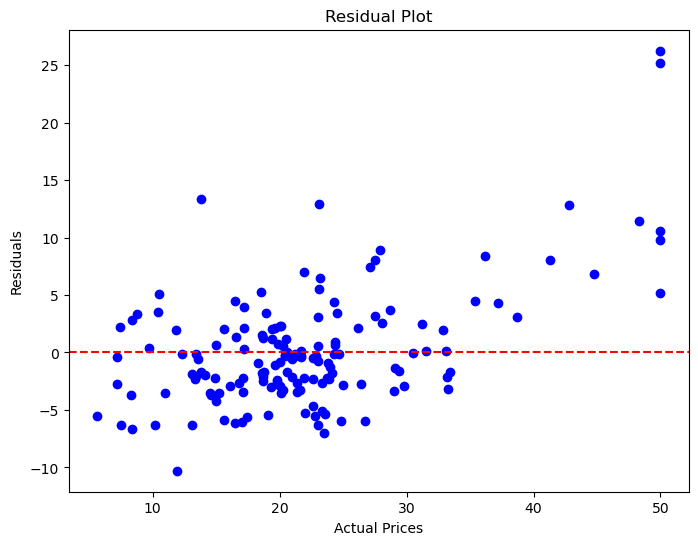

```python
import matplotlib.pyplot as plt

residuals = y_test - y_pred
print(residuals.describe())

plt.figure(figsize=(8, 6))
plt.scatter(y_test, residuals, color='blue')
plt.axhline(y=0, color='red', linestyle='--')  # Horizontal line at y=0
plt.xlabel('Actual Prices')
plt.ylabel('Residuals')
plt.title('Residual Plot')
plt.show()
```

#### Interpretation:

- In the residual plot, each point represents a house, with the x-coordinate as the actual price and the y-coordinate as the residual (the difference between the actual and predicted price).
- The red dashed line at y=0 represents no residual, or perfect prediction.
- Points above the line have been under-predicted by the model (actual price > predicted price), and points below the line have been over-predicted (actual price < predicted price).
- Ideally, the points should be randomly and evenly distributed around the y=0 line, with no clear patterns. This would indicate that the model’s errors are random and not correlated with the actual prices.

#### Exercise 5 Building and Analyzing a Polynomial Regression Model

#### Polynomial Model

A polynomial model is a type of regression model that fits a polynomial equation to a set of data points. Polynomial regression extends linear regression, allowing for the modeling of relationships between a dependent variable and an independent variable as an n degree polynomial.

#### Advantages:

1. **Flexibility**: Polynomial models can fit a wide range of non-linear relationships.
2. **Better Fit**: Can provide a better fit to the data compared to a linear model, especially for more complex and curvilinear relationships.

#### Disadvantages:

1. **Overfitting**: Higher-degree polynomial models can easily overfit the data, capturing noise rather than underlying patterns.
2. **Computational Complexity**: The computational complexity increases with the degree of the polynomial.
3. **Extrapolation Issues**: Polynomial models can produce unreliable predictions for values of (x) outside the range of the training data.

#### Applications:

- Polynomial models are used in various fields including physics, biology, and economics to model complex relationships.
- They are used in curve fitting, where the goal is to find the polynomial equation that best fits a set of data points.

#### Overview:

In this exercise, you will build a polynomial regression model using Python. You will use the numpy and scikit-learn libraries to fit a polynomial model to a dataset, make predictions, and evaluate the model's performance. Additionally, you will visualize the results and interpret them.

#### Steps:

#### 1. Load and Visualize the Dataset:

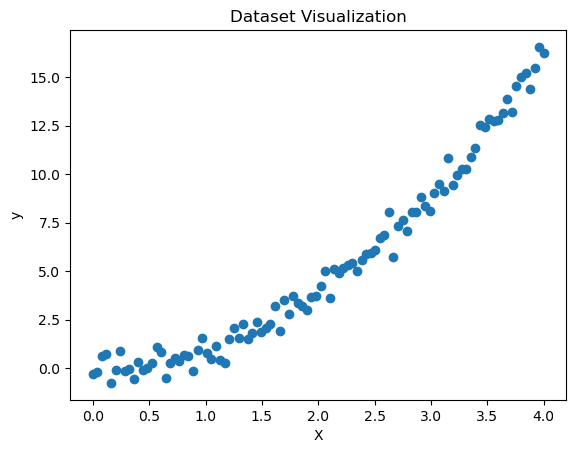

```python
import numpy as np
import matplotlib.pyplot as plt

# Generate the dataset
X = np.linspace(0, 4, 100)
y = X**2 + np.random.normal(0, 0.5, 100)

# Visualize the dataset
plt.scatter(X, y)
plt.title('Dataset Visualization')
plt.xlabel('X')
plt.ylabel('y')
plt.show()
```

#### 2. Preprocess the Dataset:

- Split the dataset into training and testing sets.
- Transform the features into polynomial features.

```python
from sklearn.model_selection import train_test_split
from sklearn.preprocessing import PolynomialFeatures

# Split the dataset
X_train, X_test, y_train, y_test = train_test_split(X, y, test_size=0.2, random_state=0)

# Transform the features
poly = PolynomialFeatures(degree=2)
X_train_poly = poly.fit_transform(X_train.reshape(-1, 1))
X_test_poly = poly.transform(X_test.reshape(-1, 1))
```

#### 3. Fit the Polynomial Model:

```python
from sklearn.linear_model import LinearRegression

# Fit the polynomial model
model = LinearRegression()
model.fit(X_train_poly, y_train)
```

```
LinearRegression()
```

#### 4. Make Predictions:

```python
# Make predictions
y_pred = model.predict(X_test_poly)
print(y_pred)
```

```
[ 0.99255993 12.07353332  0.02095118  4.80508905  9.11674339 14.17142571
  0.34739096  8.6237783   4.62555613 14.80172336  4.44945653 13.86142685
  9.88194087  0.2207899   0.06028725  1.34676031  0.69329257  0.83605962
  1.64846039  0.0784544 ]
```

#### 5. Evaluate the Model:

- Calculate the Mean Squared Error (MSE) and R-Squared score.

```python
from sklearn.metrics import mean_squared_error, r2_score

# Evaluate the model
mse = mean_squared_error(y_test, y_pred)
r2 = r2_score(y_test, y_pred)
print(f"Mean Squared Error: {mse:.2f}")
print(f"R^2 Score: {r2:.2f}")
```

```
Mean Squared Error: 0.28
R^2 Score: 0.99
```

#### 6. Visualize the Results:

- Plot the original data and the polynomial curve.

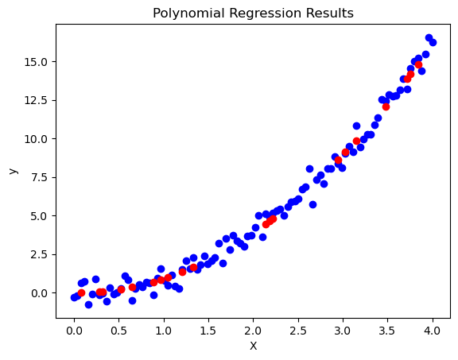

```python
# Visualize the results
plt.scatter(X, y, color='blue')
plt.scatter(X_test, y_pred, color='red')
plt.title('Polynomial Regression Results')
plt.xlabel('X')
plt.ylabel('y')
plt.show()
```

#### Interpretation:

- The plot of the original data and the polynomial curve provides a visual assessment of the model fit.
- If the polynomial curve closely follows the trend of the actual data points, it indicates a good fit.
- Look for areas where the curve does not follow the data, as these areas indicate where the model is not accurately capturing the data's structure.

#### Summary:

Regression and prediction are essential in data analysis, offering a lens to discern and quantify the intricate relationships between variables across diverse fields such as finance, healthcare, and engineering. These analytical tools illuminate the pathways of influence among variables, enabling precise predictions and informed decision-making. By modeling the interplay between dependent and independent variables, regression analysis enhances forecasting accuracy and empowers identifying significant factors and their impacts on outcomes. This insight is fundamental for effective interventions, strategy optimization, and the proactive management of various challenges and opportunities, ultimately driving progress and innovation in multiple domains.

Revised Date: October 20, 2023